# Intro to Survival Analysis

2025-04-20

# **Introduction to Survival Analysis** (KACY’S PART)

[figure not shown]

In this module, we’ll explore how to model time-to-event data using R. You’ll learn how to analyze and visualize a variety of methods to understand survival patterns — even when we don’t have the complete data for every individual.

## **Objectives**

The objective of this module is to provide an applied introduction to survival analysis using R. To complete this module, prior familiarity with R syntax and basic statistical concepts such as regression and probability, is expected.

## **What is Survival Analysis?**

Imagine you’re tracking patients in a clinical trial to see how long it takes for them to recover. Not all patients finish the study, and some will never experience the event (recovery) — that’s where survival analysis comes in!

Key Idea: Time-to-Event Data In survival analysis, we care not only about what happens, but **when** it happens.

There are two ways to think about time in this framework:  
- **Points**: The exact time an event occurs (e.g., someone relapses, dies, or gets a job)  
- **Lines**: The duration from the start of observation until the event. This could be days, months, or even years.

This structure makes survival analysis unique from other statistical models. It is built to handle **incomplete information** and **uncertain timing**.

## **Key Concepts**

- **Time to event**: How long it takes until something happens
- **Censoring**: When the event is not observed, but the data is still usable
- **Survival function**: Probability of surviving past time *t*
- **Hazard function**: Instantaneous risk of the event occurring at time *t*
- **Hazard ratio**: Compares the risk between two groups (e.g., treated vs control)

## **Types of Censoring**

Survival analysis handles incomplete data using the concept of **censoring**:

[figure not shown]

- **Right censoring (most common)**: The event hasn’t happened yet, and we don’t know when (e.g., someone is still alive at study’s end)
- **Left censoring**: The event has already occurred before observation started
- **Interval censoring**: The event happened between two known time points

## **A Bit of History**

Survival analysis has deep historical roots. In 1662, **John Graunt** created one of the first **life tables** by analyzing London’s death records. His goal was to understand the patterns of mortality and lifespan — essentially starting the earliest form of population-based survival analysis.

For centuries, survival analysis was primarily used to study death and mortality rates, especially in public health. In the last few decades, this method has grown beyond medicine.

## **Core Functions**

- **Survival Function** $S(t) = P(T > t)$:  
  Represents the probability that an event has **not** occurred by time *t*
- **Hazard Function** $h(t)$:  
  Represents the **instantaneous rate** at which the event occurs at time *t*, given that the individual has survived up to that time  
  > “If someone has made it to time *t*, how likely are they to experience the event **right now**?”
- **Hazard Ratio**
  $$HR = \frac{\text{Hazard when } x =
  1}{\text{Hazard when } x = 0}$$
  Compares the risk between two groups
  > Example: An HR = 2 means one group is **twice as likely** to experience the event at a given moment than another group.

## **Why Not Traditional Models?**

[figure not shown]

Traditional Models like linear regression assume:

- Every individual has a known outcome
- No one drops out
- The timing of events isn’t important

But in the **real world**:  
- Not everyone reaches the event  
- People drop out  
- Timing matters

Survival analysis is **designed** for real-world situations!

## **Using R for survival analysis**

In this module, we’ll be applying survival techniques using R. We’ll focus on key functions such as:

- **survfit():** Estmates survival functions and generates Kaplan-Meier curves.
- **coxph():** Fits the Cox proportional hazards model to analyze the effects of covariates on survival

These functions allow us to analyze time-to-event data and assess the effects of different variables on survival outcomes.

# Fitting the Kaplan-Meier Survival Model

The **Kaplan–Meier estimator**, also known as the **product limit estimator**, is a non-parametric statistic used to estimate the survival function from lifetime data. In medical research, it is often used to measure the fraction of patients living for a certain amount of time after treatment. In other fields, Kaplan–Meier estimators may be used to measure the length of time people remain unemployed after a job loss, the time-to-failure of machine parts, or in our case, the amount of time a patient survived after being diagnosed for a disease.

For this challenge, we will start with a basic dataset of twelve Colon cancer patients in a study who have survived after diagnosis.

We will now read the dataset (Csurv) which I prepared specially for this challenge:

```r
library(readxl)

github_url <- "https://raw.githubusercontent.com/imcarlyy/survival_analysis/main/Csurv.xlsx"
temp_file <- tempfile(fileext = ".xlsx")  # Create a temporary file
download.file(github_url, temp_file, mode = "wb")  # 'wb' for binary (Excel files)
Csurv <- read_excel(temp_file)  # Read the downloaded file
unlink(temp_file)  # Delete the temporary file
```

Now I will check the names of the variables given in this table.

```r
names(Csurv)
```

```
## [1] "Time"  "Death"
```

```r
attach(Csurv) #Since, the dataset is small (n=12) we can take a look at it entirely here:
Csurv
```

```
## # A tibble: 12 × 2
##     Time Death
##    <dbl> <dbl>
##  1     2     1
##  2     3     0
##  3     6     1
##  4     6     1
##  5     7     1
##  6    10     0
##  7    15     1
##  8    15     1
##  9    16     1
## 10    27     1
## 11    30     1
## 12    32     1
```

It is very important to know while working with survival analysis datasets what the 0 and 1 stands for.

In this example we are considering Death: 1=event has occurred (death) and 0=no event (they are censored; meaning they have left the study and hence we do not know whether they have data on them at the given point of time).

So, in this dataset if we look at first column, the 1st individual died at 2 months from the start of the study (Time=2, Death=1), the 2nd individual was censored at 3 months (Time=3, Death=0), the 3rd individual died at 6 months (Time=6, Death=1) and so on.

Now we will look into the Kaplan-Meier to fit into this dataset.

In order to do this, we need to load the survival library into R. Now, the survival library is already built into base R, so we do not need to install this package, but we do need to load the package to use these survival commands.

```r
library(survival)
```

Now in order the fit the K-M model, we will use this survfit command and so I am going to fit a survival analysis, store it in an object called km.model:

```r
km.model<-survfit(Surv(Time, Death)~1, type="kaplan-meier")
```

Here, I am going to let R know the type is kaplan-meier (if we do not specify the type it will fit the kaplan-meier by default so it wouldn’t have been an issue)

Now the way we specify the survival time or the y variable is using a capital S; so it’s Surv (survival) and then in parentheses we need to give it both the time the individual was followed for as well the indicator of whether the event occured (they died) or if they were censored {*Surv(Time, Death)* tilde 1} and the reason we have one here is that for this dataset we don’t actually have any x variables. This is the way we let R know that we are just estimating survival without using any particular X variables.

Now that the model has been fit, we can ask a few summaries…

```r
km.model #Summary of the K-M model
```

```
## Call: survfit(formula = Surv(Time, Death) ~ 1, type = "kaplan-meier")
##
##       n events median 0.95LCL 0.95UCL
## [1,] 12     10     15       7      NA
```

The output we are getting here is the total number of individuals is 12, number of events is 10 (10 deaths and 2 censored observations), median survival time so, in this case half the people survived beyond 15 months, half did not. We have also returned a 95% confidence interval for the median which means that we are 95% confident that median survival is somewhere between 7 months and infinity. This dataset is very small so here we do not have a upper limit for confidence interval around the median survival.

We can also ask for the summary of the model:

```r
summary(km.model)
```

```
## Call: survfit(formula = Surv(Time, Death) ~ 1, type = "kaplan-meier")
##
##  time n.risk n.event survival std.err lower 95% CI upper 95% CI
##     2     12       1    0.917  0.0798       0.7729        1.000
##     6     10       2    0.733  0.1324       0.5148        1.000
##     7      8       1    0.642  0.1441       0.4132        0.996
##    15      6       2    0.428  0.1565       0.2089        0.876
##    16      4       1    0.321  0.1495       0.1287        0.800
##    27      3       1    0.214  0.1325       0.0635        0.720
##    30      2       1    0.107  0.1005       0.0169        0.675
##    32      1       1    0.000     NaN           NA           NA
```

Here we can see that at time 2, there were 12 individuals at risk, 1 death occurred, the probability of surviving beyond 2 months is 91.7%. We also have a standard error associated with that survival (0.0798) as well as a 95% CI (ie. we are 95% confident that beyond 2 months the patients survival chances are between 77.3% upto a 100%). Similary, at time 6, there are 10 individuals at risk, 2 individuals died and so the probabilty of surviving beyond 6 months is 73.3%. Again, the standard error at 6 months is 0.1324 and we are 95% confident that there’s somewhere between 51.5 upto 100% chance of surviving 6 months. Now these are extremely wide confidence intervals because the sample size is so small. This dataset is useful for introducing the idea of Kaplan-Meier survival model but for a real study, we would have a same size of much greater than 12.

Now we can ask R to make a plot of this model. To do that we can ask R to plot the K-M model. So R will plot the Kaplan-Meier model that was fit saying confidence interval=F (or False). It tells R to not put a confidence interval around the survival function. xlab and ylab are giving the plot x-axis and y-axis labels and the main is the title.

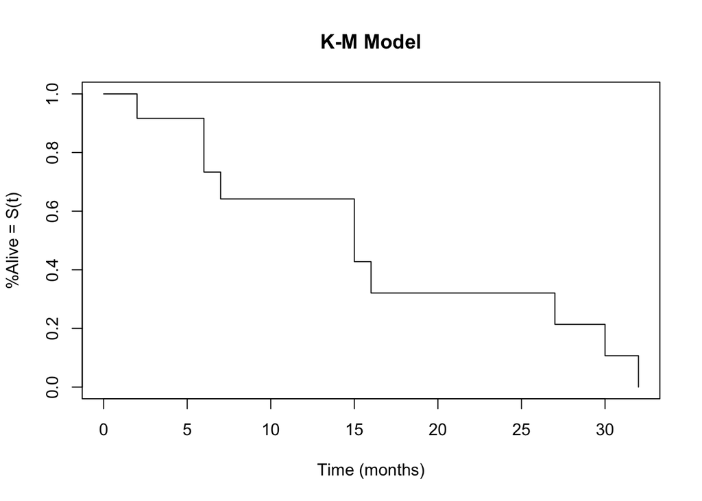

```r
plot(km.model, conf.int=F, xlab="Time (months)",ylab="%Alive = S(t)", main="K-M Model")
```

As we can see, a plot of the Kaplan–Meier is a series of declining horizontal steps.

Now if we wanted to we can ask R to put confidence interval or confidence bands around this survival function. To do so we would just set conf.int=T (or True). I will also set las=1 (this will rotate the values on the y-axis. So, here’s what it will look like:

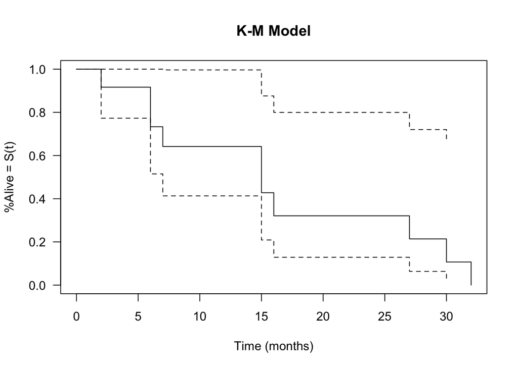

```r
plot(km.model, conf.int=T, xlab="Time (months)", ylab="%Alive = S(t)", main="K-M Model", las=1)
```

We can see now these dashed lines give us confidence interval around the survival function and we can also see that las = 1 argument rotated the values on y-axis.

Now I am going to add a red horizontal line at S(t) = 50% into this plot:

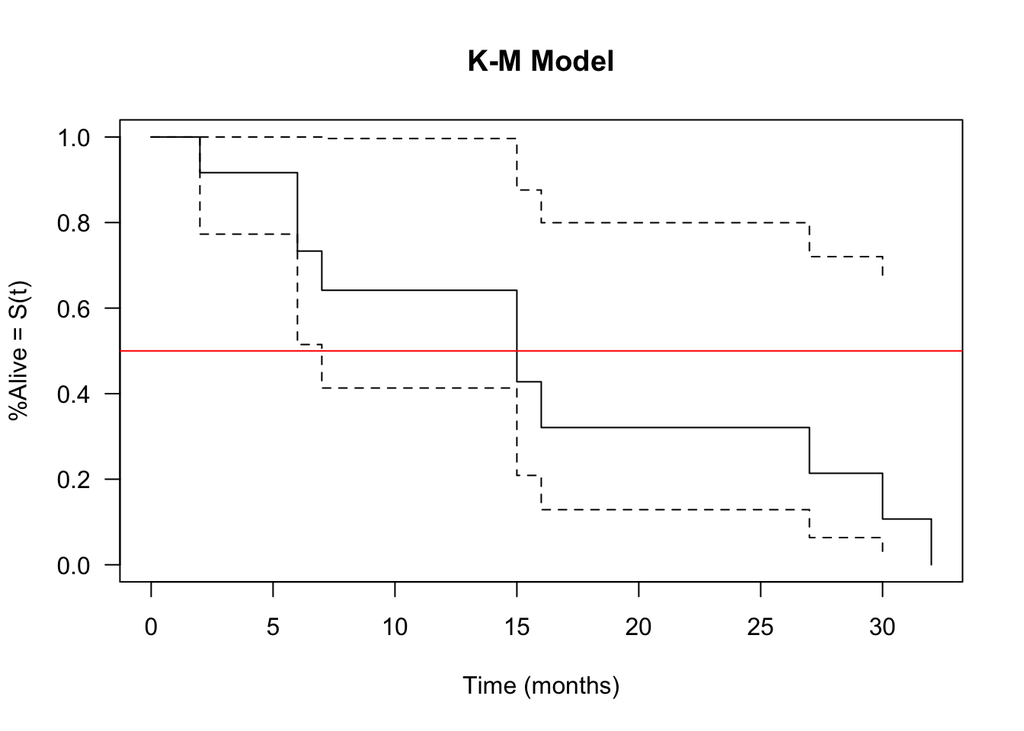

```r
plot(km.model, conf.int=T, xlab="Time (months)", ylab="%Alive = S(t)", main="K-M Model", las=1)
abline(h=0.5, col="red")
```

The red line is at 50% meaning 50% surviving 50% not. Hence, this is how we look at the median survival. Here the red line crosses the survival function right at the 15 months (this is our median). The red line passes the dashed line for lower limit at 7 months and it never hits the dashed line for upper limit (because of the smaller sample size).

Now, I am going to produce the same plot again but added mark.time=TRUE and this will add in little tick marks wherever there was a censored observation. So if you remember there was observations censored at 3 and at 10 months. So, here’s the code:

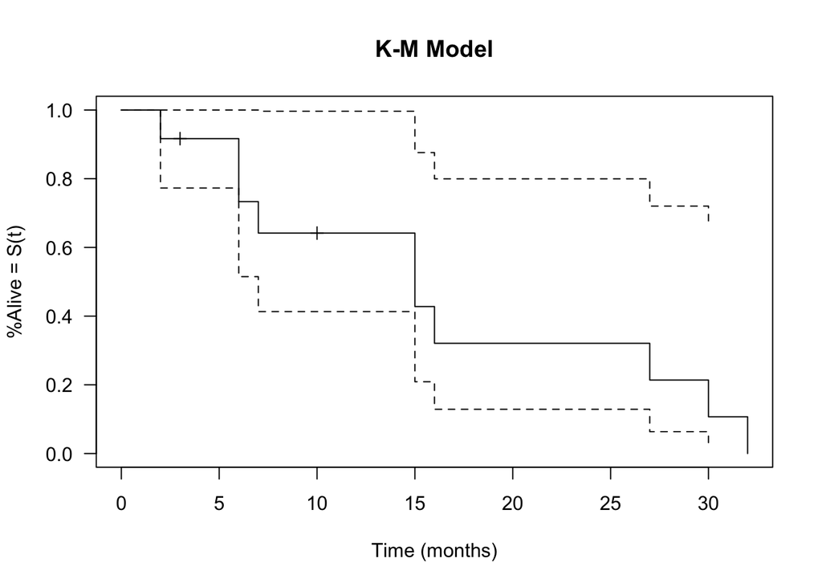

```r
plot(km.model, conf.int=T, xlab="Time (months)", ylab="%Alive = S(t)", main="K-M Model", las=1, mark.time=TRUE)
```

This helps us visualize where and when observations are censored.

Now, let’s include a x variable into fitting this model. I will continue on the same cancer patient dataset (those 12 individuals were all under 40 years old) and will add in more data points and this is going to be a group of individuals who are over 40 years old (another column Over40 will be added)

```r
rm(Csurv)
library(readxl)

github_url2 <- "https://raw.githubusercontent.com/imcarlyy/survival_analysis/main/Csurv40.xlsx"
temp_file2 <- tempfile(fileext = ".xlsx")  # Creates a temporary file path
download.file(github_url2, temp_file2, mode = "wb")  # Saves to temp_file2 (not temp_file)
Csurv40 <- read_excel(temp_file2)  # Reads from temp_file2
unlink(temp_file2)  # Deletes temp_file2
```

Taking a quick look at the new table:

```r
head(Csurv40)
```

```
## # A tibble: 6 × 3
##    Time Death Over40
##   <dbl> <dbl>  <dbl>
## 1     2     1      0
## 2     3     0      0
## 3     6     1      0
## 4     6     1      0
## 5     7     1      0
## 6    10     0      0
```

```r
tail(Csurv40)
```

```
## # A tibble: 6 × 3
##    Time Death Over40
##   <dbl> <dbl>  <dbl>
## 1     1     1      1
## 2     2     1      1
## 3     3     1      1
## 4     3     1      1
## 5     9     1      1
## 6    22     0      1
```

Over40=0 : not over 40 years old; Over40=1: Over 40 years old

Now let’s fit the K-M Model (say km.model2), relating over/under40 to survival and see if there is a relationship between survival and age:

```r
km.model2<-survfit(Surv(Time, Death)~Over40, type="kaplan-meier", data=Csurv40)
```

Plotting this:

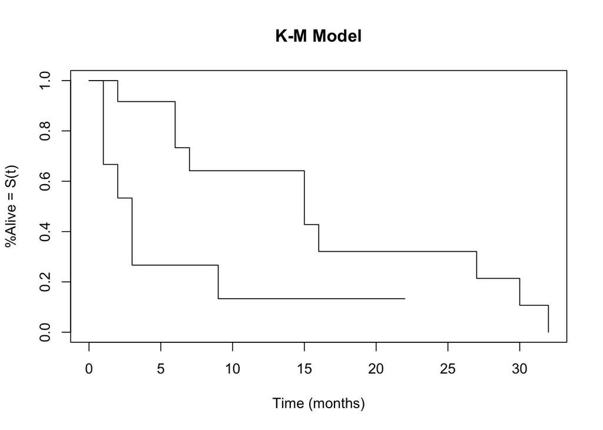

```r
plot(km.model2, conf.int=F, xlab="Time (months)", ylab="%Alive = S(t)", main="K-M Model", data=Csurv40) #conf.int=F, so we will not put the confidence bands on there for now.
```

As we can see, we clearly see a difference between under 40 and over 40 groups: Under 40 groups have a higher chance of survival than over 40 groups.

Let’s do some summaries:

```r
summary(km.model2)
```

```
## Call: survfit(formula = Surv(Time, Death) ~ Over40, data = Csurv40,
##     type = "kaplan-meier")
##
##                 Over40=0
##  time n.risk n.event survival std.err lower 95% CI upper 95% CI
##     2     12       1    0.917  0.0798       0.7729        1.000
##     6     10       2    0.733  0.1324       0.5148        1.000
##     7      8       1    0.642  0.1441       0.4132        0.996
##    15      6       2    0.428  0.1565       0.2089        0.876
##    16      4       1    0.321  0.1495       0.1287        0.800
##    27      3       1    0.214  0.1325       0.0635        0.720
##    30      2       1    0.107  0.1005       0.0169        0.675
##    32      1       1    0.000     NaN           NA           NA
##
##                 Over40=1
##  time n.risk n.event survival std.err lower 95% CI upper 95% CI
##     1      9       3    0.667   0.157       0.4200        1.000
##     2      5       1    0.533   0.173       0.2821        1.000
##     3      4       2    0.267   0.159       0.0829        0.858
##     9      2       1    0.133   0.123       0.0218        0.817
```

```r
km.model2
```

```
## Call: survfit(formula = Surv(Time, Death) ~ Over40, data = Csurv40,
##     type = "kaplan-meier")
##
##           n events median 0.95LCL 0.95UCL
## Over40=0 12     10     15       7      NA
## Over40=1  9      7      3       1      NA
```

Now, let’s make that same plot again but adding some colours, a legend and a tick at the time of censored events:

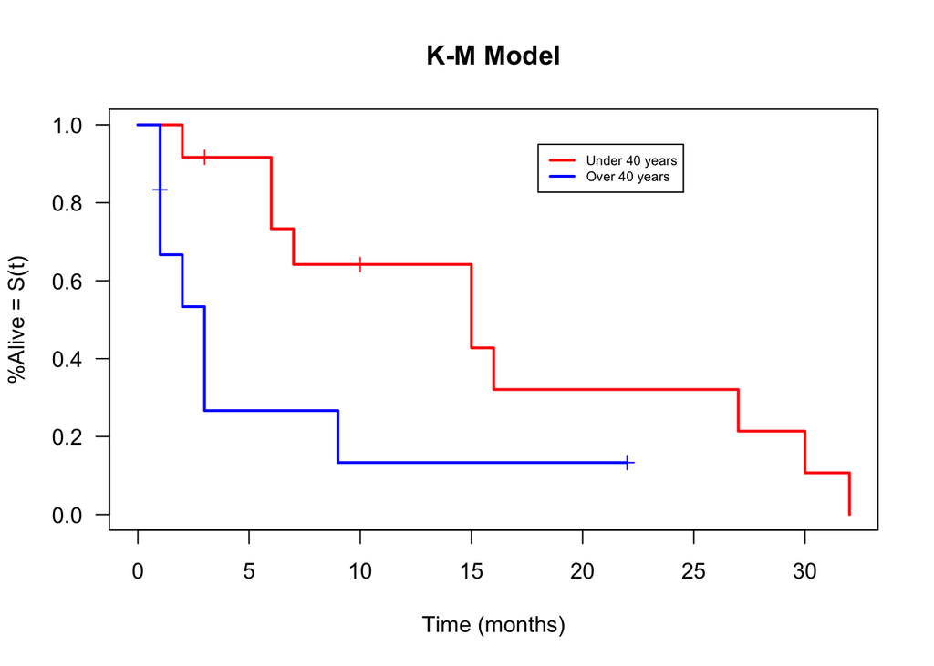

```r
plot(km.model2, conf.int=F, xlab="Time (months)", ylab="%Alive = S(t)", main="K-M Model", col=c("red","blue"), las=1, lwd=2, mark.time=TRUE, data=Csurv40 )
legend(18, 0.95, legend=c("Under 40 years", "Over 40 years"), lty=1, lwd=2, col=c("red", "blue"), bty="",cex=0.6) #adding a legend
```

An important question:

Are two survival functions are statistically significantly different? Or do you think that the survival differs if someone is over or under 40?

YES! Survival (Probability of surviving beyond a certain time) changes depending on if someone’s over or under 40. Here I will talk about the formal test for doing this.

Here comes the **Log-Rank Test**: It is a way of testing if there is a significant difference between the two survival curve. It is also known as the Mantle Hansel test.

```r
#Log-Rank Test
#Null Hypothesis: Survival for two groups is same
#Hypothesis1: Survival for two groups is not same
survdiff(Surv(Time, Death)~Over40, data=Csurv40)
```

```
## Call:
## survdiff(formula = Surv(Time, Death) ~ Over40, data = Csurv40)
##
##           N Observed Expected (O-E)^2/E (O-E)^2/V
## Over40=0 12       10    13.35     0.841      4.75
## Over40=1  9        7     3.65     3.079      4.75
##
##  Chisq= 4.8  on 1 degrees of freedom, p= 0.03
```

Test-statistic is 4.8, the p-value is 0.03. Based on this small p-value, we can reject our null hypothesis. We have evidence to believe that survival is not the same depending on if you are over or under 40.

# exercise 2: (BENJAMINS’ PART)

# Cox proportional hazard model: Checking the proportional hazards assumption

```r
library(survival)
library(survminer)
```

```r
library(ggplot2)
library(tidyr)
library(dplyr)
```

Let’s say you want to assess the role of different variables in your data in survival times. There are many models and methods to do so but the most common is to use the Cox Proportional Hazard model. First introduced in 1972, this model allows you to assess the hazard at a certain time given a specific covariate. In math terms, under the cox model our hazard function is:

[figure not shown]

Where the hazard at time t given your covariate X is equal to your baseline hazard function (with all covariates equal to 0), multiplied by your exponential function exp(BX), a multiplicative way of assessing the covariates influence on overall hazard.

Let’s load in our datasets.

```r
data(cancer)
```

As before we’ll make a survival object based on some of our data. In this case let’s use the lung cancer survival dataset:

```r
sv1 <- survfit(Surv(time, status) ~ 1, data = lung)
```

The Survival package makes fitting a CPH model to your data very easy, with just the coxph function. Say we wanted to fit a Cox regression based on age to our cancer mortality data:

```r
cx_age <- coxph(Surv(time, status) ~ age, data = lung)
cx_age
```

```
## Call:
## coxph(formula = Surv(time, status) ~ age, data = lung)
##
##         coef exp(coef) se(coef)     z      p
## age 0.018720  1.018897 0.009199 2.035 0.0419
##
## Likelihood ratio test=4.24  on 1 df, p=0.03946
## n= 228, number of events= 165
```

However, the CPH model makes some assumptions!

1. The covariates that you’re testing are constant over time.
2. Hazard ratios/proportions do not vary over time.

The second one is the most important. Put simply it means that the proportion of hazard between groups in your model is the same at every time point. This is referred to as the “proportional hazards assumption” and is the reason it’s called the Cox *Proportional Hazard* model. This limits the model’s utility, and means that we need to test to see if our data can be used with the cox model. Luckily the survival package makes this pretty straightforward using the cox.zph() function:

```r
cox.zph(cx_age)
```

```
##        chisq df    p
## age    0.346  1 0.56
## GLOBAL 0.346  1 0.56
```

The function returns a p value of 0.56, which is far above even our least stringent alpha levels so we can be pretty confident that our age data does not violate the proportional hazard assumption. Hooray!

Let’s have a look at our cox model based on age again:

```r
cx_age
```

```
## Call:
## coxph(formula = Surv(time, status) ~ age, data = lung)
##
##         coef exp(coef) se(coef)     z      p
## age 0.018720  1.018897 0.009199 2.035 0.0419
##
## Likelihood ratio test=4.24  on 1 df, p=0.03946
## n= 228, number of events= 165
```

The coefficient is positive, so we’re seeing a slight increase in the risk of an “event” (in this case death) due to age, with a significant p-value of 0.0419. Though note that this p-value is on the higher end, so we might want to take this result with a grain of salt.

## Challenge 2

Fit a CPH model to the cancer data, looking at sex in addition to age. Does our model using sex violate the proportional hazard assumption? How does it’s p-value compare to that of age? What might account for this?

```r
cx_sex <- coxph(Surv(time, status) ~ sex + age, data = lung)
cox.zph(cx_sex)
```

```
##        chisq df    p
## sex    2.608  1 0.11
## age    0.209  1 0.65
## GLOBAL 2.771  2 0.25
```

```r
cx_sex
```

```
## Call:
## coxph(formula = Surv(time, status) ~ sex + age, data = lung)
##
##          coef exp(coef)  se(coef)      z       p
## sex -0.513219  0.598566  0.167458 -3.065 0.00218
## age  0.017045  1.017191  0.009223  1.848 0.06459
##
## Likelihood ratio test=14.12  on 2 df, p=0.0008574
## n= 228, number of events= 165
```

Curiously, sex is showing a strong negative coefficient, indicating that it’s having a strong protective effect (i.e. females are surviving longer than males in this dataset), and our p-value for that is 0.002, which is significant by most metrics! That said, if we look at the cox proportional hazard assumption test our p-value associated with sex is pretty low, at 0.11. This is a little concerning, since while we’re still technically above an alpha threshold of 0.05, we might be concerned that our sex covariate is violating the proportional hazard assumption. What do our survival curves look like?

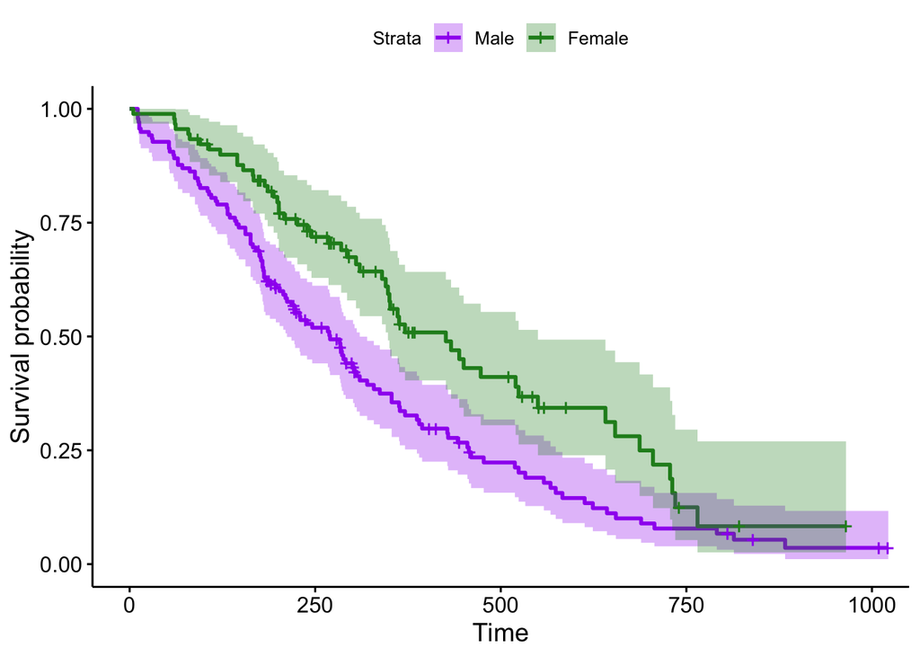

```r
ggsurvplot(
  survfit(Surv(time, status) ~ sex, data = lung),
  legend.labs = c("Male", "Female"),
  palette = c("purple","forestgreen"),
  conf.int = T
  )
```

Hmm, our survival plots seem to be drawing together towards the end of the timeframe we’re looking at. Perhaps that accounts for the low p-value in our proportional hazard test. What happens if we remove the individuals near the ends of the curves?

```r
lung_short <- lung %>%
  filter(
    time < 700
  ) %>%
  filter(
    time > 50
  )
cx_sex2 <- coxph(Surv(time, status) ~ sex + age, data = lung_short)
cox.zph(cx_sex2)
```

```
##        chisq df    p
## sex    0.575  1 0.45
## age    0.500  1 0.48
## GLOBAL 1.112  2 0.57
```

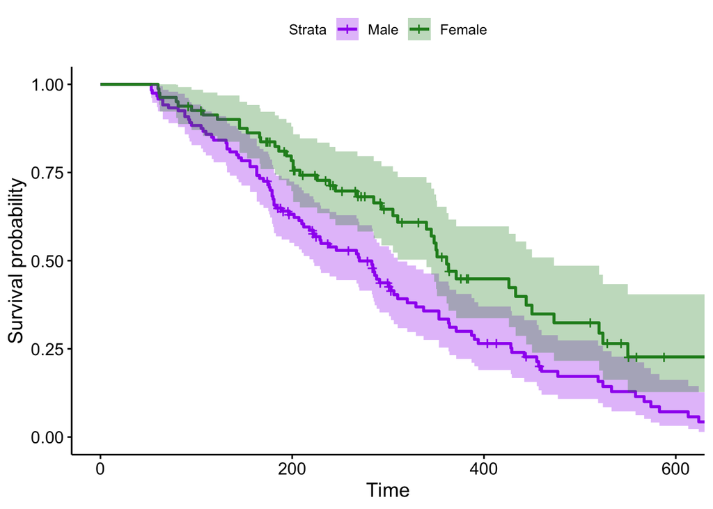

```r
ggsurvplot(
  survfit(Surv(time, status) ~ sex, data = lung_short),
  legend.labs = c("Male", "Female"),
  palette = c("purple","forestgreen"),
  conf.int = T
  )
```

Ahh, interesting! If we omit the mortality events that occurred very early and very late in our time series data, the proportional hazard due to our sex variable becomes a lot more constant. Interestingly doing this also seems to drop our age p-value, but both are now far above what we would consider a significant violation of the proportional hazard assumption.

## Challenge 3

Now let’s try what we’ve learned with some other data sets. Have a look at the colon dataset provided by the survival package. This is a survival dataset for patients with colon cancer in a chemotherapy treatment trial, with the “rx” column indicating what treatment the patients received (either “Obs” for observation only, “rxLev” for treatment with just levamisole, or “rxLev + 5FU” for levamisole & the chemotherapy agent 5-FU). Does the rx covariate violate the proportional hazard assumption? What do the survival curves look like for this data when we segregate based on treatment? Does the chemotherapy seem to work?

```r
head(colon)
```

```
##   id study      rx sex age obstruct perfor adhere nodes status differ extent
## 1  1     1 Lev+5FU   1  43        0      0      0     5      1      2      3
## 2  1     1 Lev+5FU   1  43        0      0      0     5      1      2      3
## 3  2     1 Lev+5FU   1  63        0      0      0     1      0      2      3
## 4  2     1 Lev+5FU   1  63        0      0      0     1      0      2      3
## 5  3     1     Obs   0  71        0      0      1     7      1      2      2
## 6  3     1     Obs   0  71        0      0      1     7      1      2      2
##   surg node4 time etype
## 1    0     1 1521     2
## 2    0     1  968     1
## 3    0     0 3087     2
## 4    0     0 3087     1
## 5    0     1  963     2
## 6    0     1  542     1
```

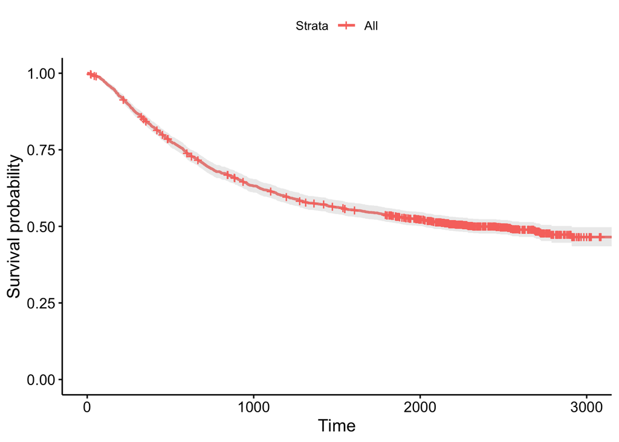

```r
ggsurvplot(
  survfit(Surv(time, status) ~ 1, data = colon),
  conf.int = T
  )
```

```r
colon_cox <- coxph(Surv(time, status) ~ rx, data = colon)
cox.zph(colon_cox)
```

```
##        chisq df    p
## rx     0.648  2 0.72
## GLOBAL 0.648  2 0.72
```

```r
colon_cox
```

```
## Call:
## coxph(formula = Surv(time, status) ~ rx, data = colon)
##
##               coef exp(coef) se(coef)      z        p
## rxLev     -0.02090   0.97932  0.07683 -0.272    0.786
## rxLev+5FU -0.44101   0.64339  0.08391 -5.256 1.47e-07
##
## Likelihood ratio test=35.23  on 2 df, p=2.233e-08
## n= 1858, number of events= 920
```

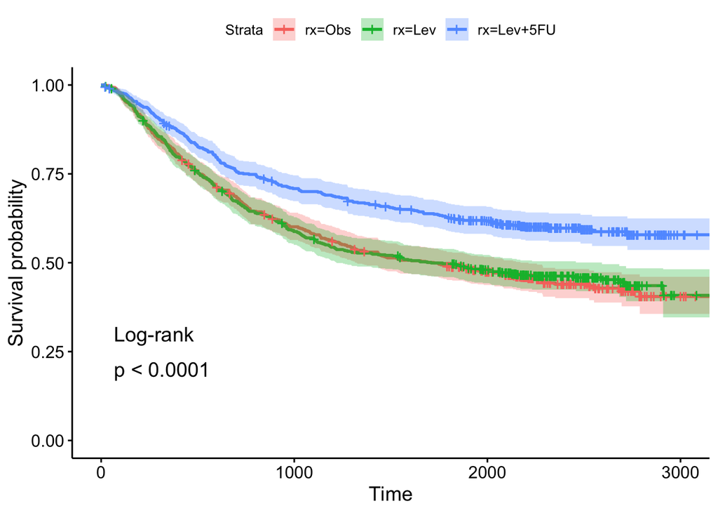

```r
ggsurvplot(
  survfit(Surv(time, status) ~ rx, data = colon),
  conf.int = T,
  pval = T,
  pval.method = T
  )
```

## Challenge 4 (TIFFANY’S PART)

One of the most common test in survival analysis is a nonparametric test known as **log-rank test,** which compares survival curves under the assumption of **proportional hazards**. It tests whether there is a **statistically significant difference** in survival between groups over time.

$H_0: S_1(t) = S_2(t) \text{ for all } t$

$H_A: S_1(t) \neq S_2(t) \text{ for some } t$

The null hypothesis states that **survival functions** $S_1(t)$ and $S_2(t)$ for the two groups are **equal at all time points** $t$**,** there is **no difference in survival** between groups over time. While the alternative hypothesis states that the **survival functions** are **not equal at some time point** $t$, so there is **a difference** in survival between the two groups.

How the log-rank test works is that is compares the **observed** number of events (e.g., deaths) in each group to the expected number under the assumptions that all group have the same survival experience. So it sums the differences over the entire study period.

$X^2 = \frac{(O_1 - E_1)^2}{V_1}$

Where:

- $O_1$ is the observed number of events in group 1
- $E_1$ is the expected number of events in group 1
- $V_1$ is the variance of difference
- This statistic follows the chi-squared distribution with 1 degree of freedom

In R, we will be using the `survdiff()` function from the `{survival}` package to perform comparisons between two groups.

Lets first compare survival times between males and females in the `Lung` dataset to help us answer the question:

- Is there a statistically significant difference in survival times between males and females?

```r
head(lung) #Display the first 6 rows of the lung dataset
```

```
##   inst time status age sex ph.ecog ph.karno pat.karno meal.cal wt.loss
## 1    3  306      2  74   1       1       90       100     1175      NA
## 2    3  455      2  68   1       0       90        90     1225      15
## 3    3 1010      1  56   1       0       90        90       NA      15
## 4    5  210      2  57   1       1       90        60     1150      11
## 5    1  883      2  60   1       0      100        90       NA       0
## 6   12 1022      1  74   1       1       50        80      513       0
```

Lets check if the survival curves follow the proportion hazard assumptions.

```r
# Fit a Cox Proportional Hazards model
cox_m1 <- coxph(Surv(time, status) ~ sex, data = lung)

# Test proportional hazards assumption
cox_t1 <- cox.zph(cox_m1)

# View the results
cox_t1
```

```
##        chisq df     p
## sex     2.86  1 0.091
## GLOBAL  2.86  1 0.091
```

The p-value for sex is greater than 0.05, then there is no evidence that proportional hazards assumption is violated for sex. Then we can move forward to perform the log-rank test between males and females.

```r
# Convert sex to a factor with appropriate labels
lung$sex <- factor(lung$sex, levels = c(1, 2), labels = c("Male", "Female"))

# Fit the Kaplan-Meier Survival Curves
fit <- survfit(Surv(time, status) ~ sex, data = lung)

# View the summary of the survival curves
summary(fit)
```

```
## Call: survfit(formula = Surv(time, status) ~ sex, data = lung)
##
##                 sex=Male
##  time n.risk n.event survival std.err lower 95% CI upper 95% CI
##    11    138       3   0.9783  0.0124       0.9542        1.000
##    12    135       1   0.9710  0.0143       0.9434        0.999
##    13    134       2   0.9565  0.0174       0.9231        0.991
##    15    132       1   0.9493  0.0187       0.9134        0.987
##    26    131       1   0.9420  0.0199       0.9038        0.982
##    30    130       1   0.9348  0.0210       0.8945        0.977
##    31    129       1   0.9275  0.0221       0.8853        0.972
##    53    128       2   0.9130  0.0240       0.8672        0.961
##    54    126       1   0.9058  0.0249       0.8583        0.956
##    59    125       1   0.8986  0.0257       0.8496        0.950
##    60    124       1   0.8913  0.0265       0.8409        0.945
```

[output cut: 142 more lines]

The `summary(fit)` tells us how the survival probabilities change over time for each male and female. To visualize this we can plot the the survival curves (Kaplan-Meier) for males and females using `ggsurvplot()` from the `survminer` package.

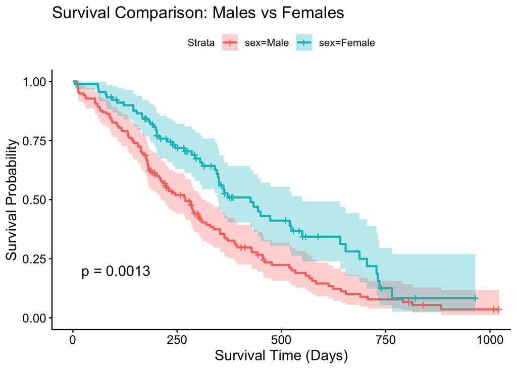

```r
ggsurvplot(fit, data = lung, pval = TRUE, conf.int = TRUE,
           title = "Survival Comparison: Males vs Females",
           xlab = "Survival Time (Days)", ylab = "Survival Probability")
```

We can see that the female survival curve in the `lung` dataset have a higher survival probability as time progresses compared to the male. This suggests that females tend to live longer than males in the study. However, how do we know this difference is significant? We will perform our **log-rank test** using `survdiff()` function from the `{survival}` to compare the survival curves of females and males

```r
# Log-Rank Test
logrank_test <- survdiff(Surv(time, status) ~ sex, data = lung)
logrank_test
```

```
## Call:
## survdiff(formula = Surv(time, status) ~ sex, data = lung)
##
##              N Observed Expected (O-E)^2/E (O-E)^2/V
## sex=Male   138      112     91.6      4.55      10.3
## sex=Female  90       53     73.4      5.68      10.3
##
##  Chisq= 10.3  on 1 degrees of freedom, p= 0.001
```

We reject the null hypothesis because the p-value is less than 0.05 significance level (p = 0.001). There is sufficient enough evidence to support that there is a statistically significant difference in survival times between males and females in the `lung` dataset.

# Challenge 5: Average Survival Curves: Comparison of Modeling Frameworks (CARLY’S PART)

In previous challenges, we used the Cox Proportional Hazards (CoxPH) model to assess how variables like sex influence survival time. However, CoxPH assumes a single type of event (for example, death), and it does not account for different causes of death or event types. However, in real-life scenarios, like the lung dataset, patients can die from various causes, some of which might prevent other events from occurring. These are called competing risks. But why compare CoxPH and CRR? The Cox Proportional Hazards (CoxPH) model is the go-to tool in many survival analyses. It’s powerful for understanding how covariates like age or sex influence risk over time — but it doesn’t account for competing events.

Now, imagine a patient could die from multiple causes (e.g., cancer vs. heart disease), and we’re only interested in one of them. If we just use CoxPH, we treat other causes of death like they never happened (we censor them), which can overestimate the probability of the event we’re focused on. That’s where the Competing Risks Regression (CRR) model steps in.

Overall, comparing CoxPH and CRR matters because:

1. They both are made to achieve different goals: CoxPH estimates relative risk (hazard ratios), but CRR gives us actual event probabilities (cumulative incidence) in the presence of competing risks.
2. They are used for different interpretations: CoxPH tells us “How much more (or less) likely is someone to experience the event if it happens?” while CRR answers “What’s the actual chance of this specific event happening over time?”
3. We use them to make different assumptions: CoxPH assumes that the hazard ratio is constant (proportional hazards), and doesn’t distinguish between causes. CRR handles competing events directly, modeling the risk of one outcome in the context of others.
4. They could show us different curves: CoxPH-based survival curves may overpredict event probabilities when competing risks are present. CRR-based cumulative incidence functions are more realistic when there are multiple possible outcomes.

Having examined the strenghts and weaknesses of the Cox Proportional Hazards (CoxPH) model, we will now explore how it compares to the Competing Risks Regression (CRR) model.

In this challenge, we’ll simulate competing risks using the weight loss variable as an indicator for increased risk of death from causes other than cancer. This will give us a more realistic understanding of survival curves and competing risks.

We’ll continue using the lung dataset and compare survival curves for sex, just like in Challenge 4, but this time we’ll simulate a competing event based on weight loss.

Step 1: We will begin loading our necessary packages:

```r
library(cmprsk)  # For competing risks regression
library(dplyr)   # For data wrangling
library(ggplot2) # For visualization
```

Step 2: We will prepare the Lung dataset. Make sure the sex variable is treated as a factor (which it should be already, but just to be safe, we’ll do it here).

```r
# Ensure 'sex' is a factor (in case it’s not already)
data(lung)
lung$sex <- factor(lung$sex, levels = c("Male", "Female"))

# Check the weight loss data
summary(lung$wt.loss)
```

```
##    Min. 1st Qu.  Median    Mean 3rd Qu.    Max.    NA's
## -24.000   0.000   7.000   9.832  15.750  68.000      14
```

Step 3: We will simulate competing risks based on weight loss

We’ll create a competing risks variable (called cr_status) based on weight loss. The idea is that significant weight loss may be an indicator of more severe health decline, increasing the likelihood of death from other causes like cardiovascular issues or infection.

For this challenge, we’ll assume that wt.loss > 5 kg correlates with a higher risk of death from other causes. We’ll simulate a second event (competing risk) for patients who meet this threshold.

So… Let’s imagine that we have a group of lung cancer patients, and we notice that those who lose more than 5 kg of weight over the course of their illness are at a significantly higher risk of death from complications like infections or heart disease. This competing risk could potentially bias our CoxPH model, which we’ll compare against the CRR model.

This is how it would like like in our code:

```r
# Simulate a competing risk based on weight loss (wt.loss > 5 kg means a higher risk of death from other causes)
lung$cr_status <- ifelse(lung$wt.loss > 5,
                          sample(c(1, 2), size = nrow(lung), replace = TRUE, prob = c(0.7, 0.3)),
                          0)

# Check the distribution of the new competing risk status
table(lung$cr_status)
```

```
##
##   0   1   2
## 101  85  28
```

Here, we: Assign 1 for death from cancer (event of interest).

Assign 2 for death from another cause (competing event).

```r
# Fit a Cox Proportional Hazards model using 'sex' as the predictor
cox_sex <- coxph(Surv(time, status) ~ sex, data = lung)
summary(cox_sex)
```

```
## Call:
## coxph(formula = Surv(time, status) ~ sex, data = lung)
##
##   n= 228, number of events= 165
##
##              coef exp(coef) se(coef)      z Pr(>|z|)
## sexFemale -0.5310    0.5880   0.1672 -3.176  0.00149 **
## ---
## Signif. codes:  0 '***' 0.001 '**' 0.01 '*' 0.05 '.' 0.1 ' ' 1
##
##           exp(coef) exp(-coef) lower .95 upper .95
## sexFemale     0.588      1.701    0.4237     0.816
##
## Concordance= 0.579  (se = 0.021 )
## Likelihood ratio test= 10.63  on 1 df,   p=0.001
## Wald test            = 10.09  on 1 df,   p=0.001
## Score (logrank) test = 10.33  on 1 df,   p=0.001
```

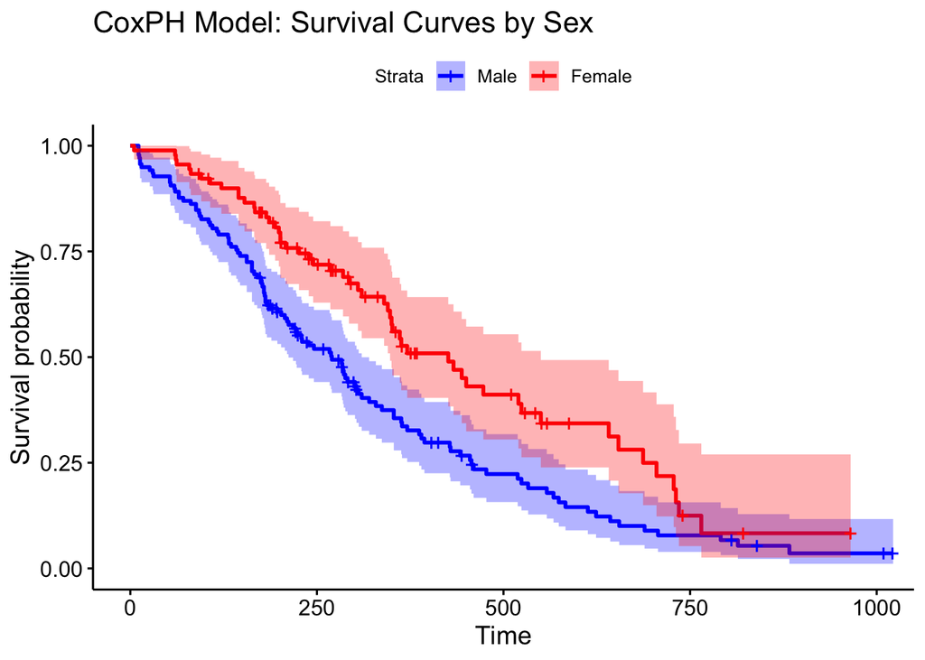

```r
# Plot the survival curves from the CoxPH model
ggsurvplot(survfit(Surv(time, status) ~ sex, data = lung),
           conf.int = TRUE,
           title = "CoxPH Model: Survival Curves by Sex",
           legend.labs = c("Male", "Female"),
           palette = c("blue", "red"))
```

Step 5: Fitting a Competing Risks Regression (CRR) Model Now, we’ll fit the CRR model (Fine and Gray method) using the newly created competing risk variable (cr_status). This model explicitly accounts for the competing risk and helps us understand how survival probabilities change when competing risks are considered.

```r
# Fit a Competing Risks Regression model using Fine and Gray's method
crr_model <- with(lung, crr(ftime = time, fstatus = cr_status, cov1 = model.matrix(~ sex)[, -1]))
```

```
## 14 cases omitted due to missing values
```

```r
summary(crr_model)
```

```
## Competing Risks Regression
##
## Call:
## crr(ftime = time, fstatus = cr_status, cov1 = model.matrix(~sex)[,
##     -1])
##
##                             coef exp(coef) se(coef)     z p-value
## model.matrix(~sex)[, -1]1 -0.558     0.572    0.225 -2.48   0.013
##
##                           exp(coef) exp(-coef)  2.5% 97.5%
## model.matrix(~sex)[, -1]1     0.572       1.75 0.368 0.889
##
## Num. cases = 214 (14 cases omitted due to missing values)
## Pseudo Log-likelihood = -390
## Pseudo likelihood ratio test = 5.96  on 1 df,
```

```r
# Plot the cumulative incidence curves (CRR model)
cif <- with(lung, cuminc(ftime = time, fstatus = cr_status, group = sex))
```

```
## 14 cases omitted due to missing values
```

[figure not shown]

```r
# Plot the cumulative incidence curves
plot(cif, xlab = "Time (Days)", ylab = "Cumulative Incidence",
     main = "CRR Model: Cumulative Incidence by Sex",
     col = c("blue", "red"))
legend("bottomright", legend = names(cif), col = c("blue", "red"), lty = 1)
```

This will generate cumulative incidence functions (CIF), which show the probability of death from cancer (the event of interest) and death from other causes (competing event) over time, adjusted for sex.

So, we comparing our models. What difference have we seen?

The CoxPH model treats competing events as censored, which can lead to overestimations of survival probabilities in the presence of competing risks.

The CRR model explicitly accounts for competing risks, giving a more realistic picture of survival probabilities when studying specific causes of death.

# **Conclusion:**

Survival analysis is a powerful tool for studying the timing of events, especially when dealing with incomplete or censored data.  
In this module, you’ve learned how to apply key survival analysis techniques in R, including the Kaplan-Meier estimator and Cox proportional hazards model. These methods are essential for analyzing real-world data where timing matters.

By the end, you should feel more confident working with time-to-event data, interpreting survival curves, comparing groups, and understanding how risk changes over time.

# **References:**

Bryan Lau, Stephen R. Cole, Stephen J. Gange, Competing Risk Regression Models for Epidemiologic Data, American Journal of Epidemiology, Volume 170, Issue 2, 15 July 2009, Pages 244–256, https://doi.org/10.1093/aje/kwp107

Camilleri, L. (2019, March 24). History of survival analysis. The Sunday Times of Malta, p. 53. Retrieved from https://www.um.edu.mt/library/oar/handle/123456789/55748

Wikipedia contributors. (n.d.). Survival analysis. Wikipedia. Retrieved April 21, 2025, from https://en.wikipedia.org/wiki/Survival_analysis

Zhang Z, Cortese G, Combescure C, Marshall R, Lee M, Lim HJ, Haller B; written on behalf of AME Big-Data Clinical Trial Collaborative Group. Overview of model validation for survival regression model with competing risks using melanoma study data. Ann Transl Med. 2018 Aug;6(16):325. doi: 10.21037/atm.2018.07.38. PMID: 30364028; PMCID: PMC6186983.